# Datos notas alumnos PROVISIONAL

Juan Gabriel Gomila & Ricardo Alberich

02/05/2019

# 1 Datos notas alumnos

Hemos preguntado a varios alumnos de MATIII algunos datos sobre sus notas.

## 1.1 Librerías necesarias

Lo primero es cargar las librerías necesarias para este ejercicio

```r
library(knitr)
#path="pon tu path"
#path="~/Documentos/docencia/docencia1819/MATIIIMaterial/Estadística/Talleres_MatIII_GINF/ContrastesNotas/IntervalosMatesII.tar.gz"
#install.packages(path, repos = NULL, type = "source")
library(IntervalosMatesII)
#help(package="IntervalosMatesII")
```

## 1.2 Lectura de datos de Google Drive

En primer lugar vamos a leer los datos que vosotros mismos (u otros alumnos de otros años) habéis ido rellenando en Google Drive. Si queréis añadir vuestros datos, lo podéis hacer antes de realizar vuestro propio análisis [aquí](https://docs.google.com/forms/d/e/1FAIpQLSfHaH-h-JljDQTZopYaVg8Y9pHPO3NcmcrN2tEZQUdM7vptBw/viewform?usp=sf_link#responses). Para hacerlo, leeremos un CSV y, le cambiaremos las comas decimales que utiliza la hoja de cálculo por el punto decimal estándar de **R** y así tendremos datos numéricos.

```r
myurl ="https://docs.google.com/spreadsheets/d/1PWWLkVNkHFec5ubwDffVYq_3Cs6Ek-QDp22gCyycu0s/pub?gid=373122346&single=true&output=csv"
rawdata = read.csv(url(myurl),dec=",", stringsAsFactors=FALSE)
knitr::kable(rawdata,digits = 2,aling="c",
             caption="Valores originales de la encuesta del alumnado de Mates III")
```

Valores originales de la encuesta del alumnado de Mates III

| gender | birthdate | yearsInCollege | height | weight | bachellorMark | selectivityMark | discreteMark | statisticsMark | studyingHours |
| --- | --- | --- | --- | --- | --- | --- | --- | --- | --- |
| Mujer | 17/03/1998 | 1 | 155.5 | 65.5 | 9.5 | 7.5 | 5.5 | 2.5 | 3.5 |
| Mujer | 1/06/1998 | 1 | 175.5 | 75.5 | 9.5 | 12.5 | 6.5 | 5.5 | 5.5 |
| Hombre | 19/03/1998 | 1 | 165.5 | 65.5 | 8.5 | 6.5 | 5.5 | 3.5 | 8.0 |
| Hombre | 28/02/1996 | 3 | 175.5 | 85.5 | 9.5 | 9.5 | 7.5 | 3.5 | 2.5 |
| Hombre | 29/07/1997 | 1 | 175.5 | 75.5 | 8.5 | 7.5 | 4.5 | 4.5 | 4.5 |
| Mujer | 17/12/1998 | 1 | 165.5 | 55.5 | 9.5 | 10.5 | 5.5 | 4.5 | 4.5 |
| Mujer | 22/04/1998 | 1 | 165.5 | 55.5 | 8.5 | 11.5 | 5.5 | 5.5 | 1.5 |
| Mujer | 18/01/1997 | 2 | 165.5 | 75.5 | 8.5 | 10.5 | 3.5 | 4.5 | 2.5 |
| Hombre | 18/08/1998 | 1 | 175.5 | 65.5 | 7.5 | 10.5 | 4.5 | 2.5 | 3.5 |
| Mujer | 12/03/1998 | 1 | 165.5 | 55.5 | 8.5 | 11.5 | 5.5 | 2.5 | 3.5 |
| Mujer | 11/12/1998 | 1 | 155.5 | 65.5 | 7.5 | 7.5 | 5.5 | 4.5 | 5.5 |
| Hombre | 19/05/1988 | 5 | 165.5 | 75.5 | 9.5 | 8.5 | 8.5 | 9.5 | 5.5 |
| Mujer | 8/11/1998 | 1 | 165.5 | 65.5 | 8.5 | 10.5 | 4.5 | 2.5 | 6.5 |
| Hombre | 14/07/1998 | 1 | 175.5 | 75.5 | 9.5 | 9.5 | 2.5 | 5.5 | 1.5 |
| Hombre | 7/07/1998 | 1 | 175.5 | 65.5 | 9.5 | 11.5 | 3.5 | 4.5 | 1.5 |
| Hombre | 15/06/1996 | 2 | 185.5 | 85.5 | 7.5 | 5.5 | 4.5 | 2.5 | 1.5 |
| Hombre | 5/09/1996 | 3 | 175.5 | 45.5 | 8.5 | 6.5 | 5.5 | 5.5 | 3.5 |
| Mujer | 26/07/1998 | 1 | 155.5 | 45.5 | 9.5 | 11.5 | 7.5 | 7.5 | 8.0 |
| Mujer | 15/04/1998 | 1 | 165.5 | 65.5 | 8.5 | 8.5 | 2.5 | 3.5 | 2.5 |
| Hombre | 13/11/1998 | 1 | 185.5 | 75.5 | 6.5 | 5.5 | 2.5 | 1.5 | 3.5 |
| Hombre | 7/01/1998 | 1 | 185.5 | 75.5 | 9.5 | 12.5 | 7.5 | 5.5 | 1.5 |
| Hombre | 25/08/1998 | 1 | 165.5 | 75.5 | 8.5 | 9.5 | 5.5 | 2.5 | 1.0 |
| Hombre | 26/11/1999 | 2 | 175.5 | 55.5 | 7.5 | 5.5 | 6.5 | 8.5 | 1.5 |
| Hombre | 26/11/1999 | 2 | 175.5 | 55.5 | 7.5 | 5.5 | 6.5 | 8.5 | 1.5 |
| Mujer | 18/03/2000 | 1 | 185.5 | 65.5 | 8.5 | 12.5 | 7.5 | 7.5 | 1.0 |
| Hombre | 29/11/1999 | 2 | 185.5 | 65.5 | 8.5 | 5.5 | 5.5 | 4.5 | 1.0 |
| Hombre | 8/08/2000 | 1 | 175.5 | 55.5 | 7.5 | 11.5 | 6.5 | 6.5 | 0.0 |
| Hombre | 22/04/1999 | 1 | 185.5 | 45.5 | 6.5 | 5.5 | 6.5 | 4.5 | 1.5 |
| Hombre | 24/01/2000 | 1 | 175.5 | 65.5 | 6.5 | 7.5 | 8.5 | 7.5 | 2.5 |
| Hombre | 16/05/2000 | 1 | 175.5 | 55.5 | 9.5 | 7.5 | 7.5 | 8.5 | 8.0 |
| Hombre | 3/09/2000 | 1 | 175.5 | 75.5 | 9.5 | 13.5 | 9.5 | 9.5 | 1.5 |

## 1.3 Creación de funciones

Declararemos las funciones que nos serán útiles durante todo el ejercicio.

```r
estadisticos=function(x)
{
  N=as.numeric(table(!is.na(x))["TRUE"])
  NAs=length(x)-N

  confInt = 0

  if(N<40){
    confInt = ICT.exact(x,na.rm=TRUE)
  } else {
    confInt = ICZ.approx(x,na.rm=TRUE)
  }

  return(c(N=N,NAs=NAs,media=mean(x),Varianza=var(x),Des_tip=sd(x),
           Q1=quantile(x,0.25),Q3=quantile(x,0.75),mediana=median(x),
           Max=max(x),Min=min(x), icLower = confInt$lower,
           ucUpper = confInt$upper))
}
```

1. Explicad el código anterior
2. Aplicad la función `estadisticos` a la variable `studyingHours`.

**Soluciones**

```r
estadisticos(rawdata$studyingHours)
```

```
##         N       NAs     media  Varianza   Des_tip    Q1.25%    Q3.75%
## 31.000000  0.000000  3.225806  5.080645  2.254029  1.500000  4.500000
##   mediana       Max       Min   icLower   ucUpper
##  2.500000  8.000000  0.000000  2.399022  4.052591
```

## 1.4 Análisis preliminar y estadística descriptiva

En primer lugar haremos un análisis preliminar, veremos un resumen de qué datos han aportado los estudiantes, y haremos también algunos gráficos histogramas, boxplots, pie charts…

```r
aux=apply(rawdata[,3:10],2,estadisticos)

knitr::kable(t(round(aux,2)),digits = 2,aling="c",caption="Estadísticos básicos toda la muestra")
```

Estadísticos básicos toda la muestra

|  | N | NAs | media | Varianza | Des_tip | Q1.25% | Q3.75% | mediana | Max | Min | icLower | ucUpper |
| --- | --- | --- | --- | --- | --- | --- | --- | --- | --- | --- | --- | --- |
| yearsInCollege | 31 | 0 | 1.42 | 0.78 | 0.89 | 1.0 | 1.5 | 1.0 | 5.0 | 1.0 | 1.09 | 1.74 |
| height | 31 | 0 | 172.60 | 81.29 | 9.02 | 165.5 | 175.5 | 175.5 | 185.5 | 155.5 | 169.29 | 175.90 |
| weight | 31 | 0 | 65.50 | 120.00 | 10.95 | 55.5 | 75.5 | 65.5 | 85.5 | 45.5 | 61.48 | 69.52 |
| bachellorMark | 31 | 0 | 8.47 | 0.97 | 0.98 | 7.5 | 9.5 | 8.5 | 9.5 | 6.5 | 8.11 | 8.83 |
| selectivityMark | 31 | 0 | 9.02 | 6.52 | 2.55 | 7.0 | 11.5 | 9.5 | 13.5 | 5.5 | 8.08 | 9.95 |
| discreteMark | 31 | 0 | 5.76 | 3.20 | 1.79 | 4.5 | 7.0 | 5.5 | 9.5 | 2.5 | 5.10 | 6.41 |
| statisticsMark | 31 | 0 | 5.15 | 5.24 | 2.29 | 3.5 | 7.0 | 4.5 | 9.5 | 1.5 | 4.31 | 5.98 |
| studyingHours | 31 | 0 | 3.23 | 5.08 | 2.25 | 1.5 | 4.5 | 2.5 | 8.0 | 0.0 | 2.40 | 4.05 |

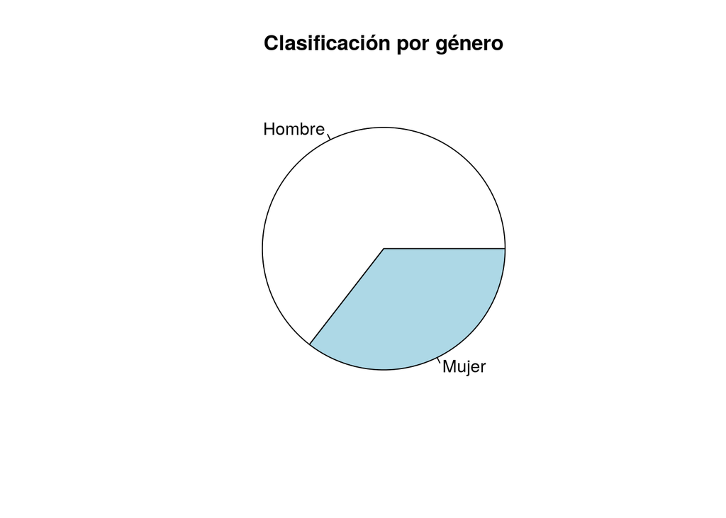

```r
pie(table(rawdata$gender), main = "Clasificación por género")
```

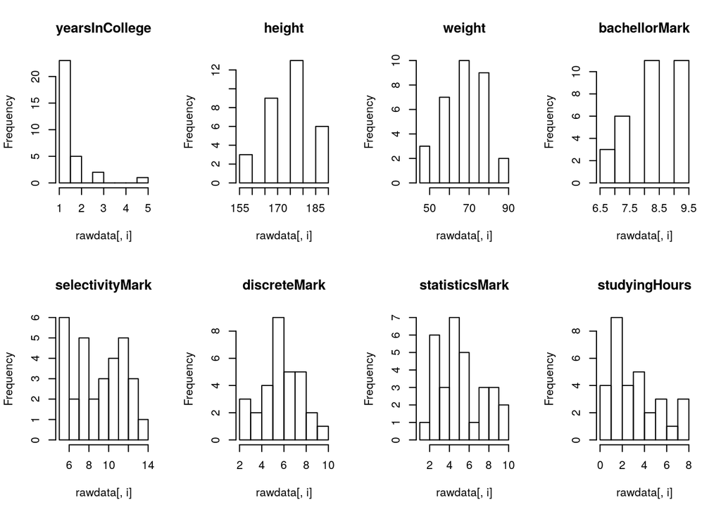

```r
par(mfrow=c(2,4))
for(i in 3:10)
  hist(rawdata[,i], main = names(rawdata)[i])
```

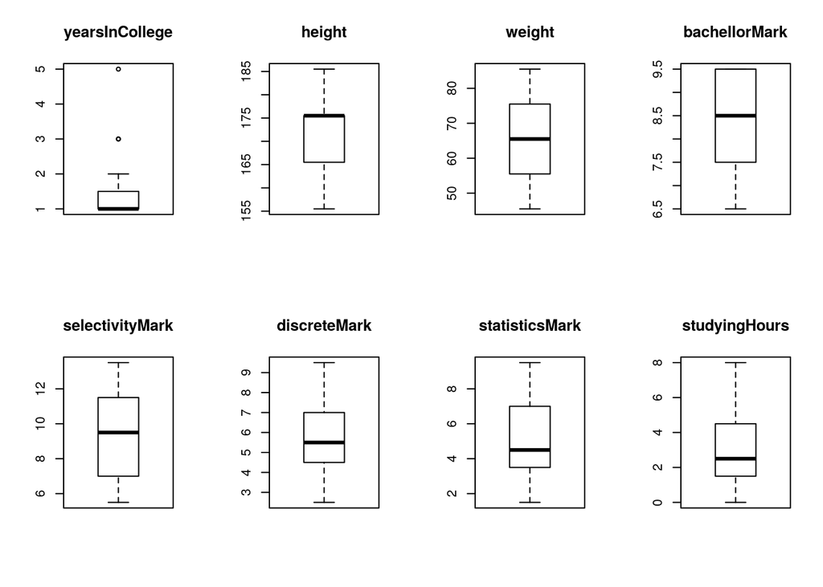

```r
for(i in 3:10)
  boxplot(rawdata[,i], main = names(rawdata)[i])
```

## 1.5 Estimación puntual

1. Calculad los estimadores de la media de les notas del dataset y el error estándar de los mismos.
2. Calculad los estimadores de las proporciones de aprobados en cada una de las asignaturas y su error estándar.

**Solución**

```r
notas=rawdata[,c(6:9)]
head(notas)
```

```
##   bachellorMark selectivityMark discreteMark statisticsMark
## 1           9.5             7.5          5.5            2.5
## 2           9.5            12.5          6.5            5.5
## 3           8.5             6.5          5.5            3.5
## 4           9.5             9.5          7.5            3.5
## 5           8.5             7.5          4.5            4.5
## 6           9.5            10.5          5.5            4.5
```

```r
apply(notas,2,mean)
```

```
##   bachellorMark selectivityMark    discreteMark  statisticsMark
##        8.467742        9.016129        5.758065        5.145161
```

```r
apply(notas,2,FUN=function(x)(sd(x)/sqrt(length(x))))
```

```
##   bachellorMark selectivityMark    discreteMark  statisticsMark
##       0.1764883       0.4587758       0.3211798       0.4110003
```

## 1.6 Intervalos de confianza

1. Calculad los intervalos de confianza con las estimaciones puntuales del apartado anterior. Podéis emplear las funciones de la librería de *IntervalosMatesII* que consideréis oportunas.
2. Cuando sea posible repetid el cálculo manualmente.

**Solución**

```r
ICT.exact(notas$bachellorMark)
```

```
##       mean size    lower    upper conf.level
## 1 8.467742   31 8.107305 8.828179       0.95
```

```r
ICZ.approx(notas$bachellorMark)
```

```
##       mean size    lower    upper conf.level
## 1 8.467742   31 8.121831 8.813653       0.95
```

$$\left(\overline{x}-t_{n-1,1-\alpha/2} \frac{\tilde{s}}{\sqrt{n}},\overline{x}+t_{n-1,1-\alpha/2} \frac{\tilde{s}}{\sqrt{n}}\right)$$

```r
media=mean(notas$bachellorMark)
media
```

```
## [1] 8.467742
```

```r
sdn=sd(notas$bachellorMark)
sdn
```

```
## [1] 0.9826451
```

```r
n=length(notas$bachellorMark)
sdn
```

```
## [1] 0.9826451
```

```r
alpha=0.05
cuantil_t=qt(1-alpha/2,n-1)
cuantil_t
```

```
## [1] 2.042272
```

```r
c(media-cuantil_t*sdn/sqrt(n),media+cuantil_t*sdn/sqrt(n))
```

```
## [1] 8.107305 8.828179
```

```r
media+c(-1,1)*cuantil_t*sdn/sqrt(n)
```

```
## [1] 8.107305 8.828179
```

$$\left(\overline{x}-z_{1-\alpha/2} \frac{\tilde{s}}{\sqrt{n}},\overline{x}+z_{1-\alpha/2} \frac{\tilde{s}}{\sqrt{n}}\right)$$

```r
cuantil_z=qnorm(1-alpha/2)
media+c(-1,1)*cuantil_z*sdn/sqrt(n)
```

```
## [1] 8.121831 8.813653
```

## 1.7 Contrastes de hipótesis de una muestra

1. Contrastad que la nota media de mates en la selectividad es superior o igual 8 contra que es menor.
2. Contrastad que les horas medias de estudio estadística son inferiores o iguales a les 4 horas semanal contra que no.
3. Contrastad que el porcentaje de aprobados a discreta es inferior o igual al 30 por cent contra que no.
4. Calculad intervalos de confianza asociados a los contrastes anteriores al nivel de confianza del 95%.
5. Cuando sea posible repetir los cálculos manualmente.

**Solución**

El contraste de la pregunta 1 es

$$\left\{
\begin{matrix}
H_0: &\mu\geq 8 \\
H_1: &\mu <8
\end{matrix}
\right.$$

```r
media=mean(notas$selectivityMark)
media
```

```
## [1] 9.016129
```

```r
n=length(notas$selectivityMark)
n
```

```
## [1] 31
```

```r
sds=sd(notas$selectivityMark)
sds
```

```
## [1] 2.554355
```

```r
mu0=8
z=(media-8)/(sds/sqrt(n))
z
```

```
## [1] 2.214871
```

```r
qnorm(0.05)
```

```
## [1] -1.644854
```

```r
z<qnorm(0.05)
```

```
## [1] FALSE
```

No conocemos la distribución de la población y la varianza es desconocida, bajo estas condiciones el estadístico de contraste es

$$Z=\frac{\overline{X}-8}{\frac{\tilde{S}}{\sqrt{n}}}$$

el valor del estadístico de contraste es

$$z=\frac{9.016129-8}{\frac{2.5543553}{\sqrt{31}}}=
2.2148708.$$

Rechazamos $H_0$ si $z< z_{0.05}=-1.6448536$. Como no es así no podemos rechazar que la media de la nota de selectividad sea mayor o igual a 8.

Calculemos el $p$-valor es $P(Z\leq z=2.2148708)=0.9866155.$ Es un $p$-valor muy grande no podemos rechazar $H_0$ contra $H_1$.

El intervalo de confianza es

$$\left]-\infty,\overline{X}-z_{\alpha}\cdot \frac{\tilde{S}}{\sqrt{n}}\right).$$

Si suponemos que la distribución de la nota es normal normal entonces podemos aplicar un $t$-test con R es

```r
t.test(rawdata$selectivityMark,mu=8,alternative = "less",conf.level = 0.95)
```

```
##
##  One Sample t-test
##
## data:  rawdata$selectivityMark
## t = 2.2149, df = 30, p-value = 0.9827
## alternative hypothesis: true mean is less than 8
## 95 percent confidence interval:
##      -Inf 9.794791
## sample estimates:
## mean of x
##  9.016129
```

Manualmente el estadístico de contraste es

$$T=\frac{\overline{X}-8}{\frac{\tilde{S}}{\sqrt{n}}}$$

el valor del estadístico de contraste es

```r
media =mean(rawdata$selectivityMark)
media
```

```
## [1] 9.016129
```

```r
sds=sd(rawdata$selectivityMark)
sds
```

```
## [1] 2.554355
```

```r
mu0
```

```
## [1] 8
```

```r
n=length(rawdata$selectivityMark)
n
```

```
## [1] 31
```

```r
T=(media-mu0)/(sds/sqrt(n))
T
```

```
## [1] 2.214871
```

```r
pvalor=pt(T,n-1)
pvalor
```

```
## [1] 0.9827466
```

$$t=\frac{9.016129-8}{\frac{2.5543553}{\sqrt{31}}}= 2.2148708.$$
que sigue una distribución $t_{n-1}=t_{31-1}=t_{30}.$

El $p$-valor del contraste es $P(t_{30}\leq 2.2148708)=0.9827466$ que es un valor muy alto por lo que no podemos rechazar la hipótesis nula.

Para media de las horas de estudio

$$\left\{
\begin{matrix}
H_0: &\mu_h\leq 4 \\
H_1: &\mu_h >4
\end{matrix}
\right.$$

```r
t.test(rawdata$studyingHours,mu=4,alternative = "great")
```

```
##
##  One Sample t-test
##
## data:  rawdata$studyingHours
## t = -1.9124, df = 30, p-value = 0.9673
## alternative hypothesis: true mean is greater than 4
## 95 percent confidence interval:
##  2.538695      Inf
## sample estimates:
## mean of x
##  3.225806
```

Sea $p=$proporción aprobados en discreta nos piden si

$$\left\{
\begin{matrix}
H_0: &p \leq 0.3 \\
H_1: &p > 0.3
\end{matrix}
\right.$$

```r
summary(rawdata$discreteMark)
```

```
##    Min. 1st Qu.  Median    Mean 3rd Qu.    Max.
##   2.500   4.500   5.500   5.758   7.000   9.500
```

```r
aprobados=rawdata$discreteMark>=5
table(aprobados)
```

```
## aprobados
## FALSE  TRUE
##     9    22
```

```r
numaprobados=table(aprobados)[2]
numaprobados
```

```
## TRUE
##   22
```

```r
N=length(rawdata$discreteMark)
N
```

```
## [1] 31
```

```r
table(aprobados)[2]
```

```
## TRUE
##   22
```

```r
phat=table(aprobados)[2]/N
phat
```

```
##      TRUE
## 0.7096774
```

```r
prop.table(table(aprobados))[2]
```

```
##      TRUE
## 0.7096774
```

```r
Z=(phat-0.3)/(sqrt(0.3*(1-0.3)/(n)))
Z
```

```
##     TRUE
## 4.977522
```

```r
Z^2
```

```
##     TRUE
## 24.77573
```

```r
prop.test(22,31,p=0.30,alternative = "great",correct=TRUE)
```

```
##
##  1-sample proportions test with continuity correction
##
## data:  22 out of 31, null probability 0.3
## X-squared = 22.863, df = 1, p-value = 8.697e-07
## alternative hypothesis: true p is greater than 0.3
## 95 percent confidence interval:
##  0.5464757 1.0000000
## sample estimates:
##         p
## 0.7096774
```

```r
# Es el mismo test de los resúmenes lo que pasa  es que hace un X^2 en lugar de un Z
sqrt(prop.test(22,31,p=0.30,alternative = "great",correct=FALSE)$statistic)
```

```
## X-squared
##  4.977522
```

```r
Z
```

```
##     TRUE
## 4.977522
```

```r
pvalorZ=1-pnorm(Z)
pvalorZ
```

```
##         TRUE
## 3.220166e-07
```

```r
pvalorX2=1-pchisq(Z^2,1)
pvalorX2
```

```
##         TRUE
## 6.440332e-07
```

$$\left\{
\begin{matrix}
H_0: &\mu\geq 8 \\
H_1: &\mu <8
\end{matrix}
\right.$$

## 1.8 Contrastes de hipótesis de dos muestras

1. Contrastad que la nota media de mates en la selectividad es igual entre les poblaciones de hombres y mujeres.
2. Contrastad que la media de horas de estudio de estadística son iguales entre les poblaciones de hombres y mujeres.
3. Contrastad que el porcentaje de aprobados de discreta es mayor en la población de homes que en la de mujeres.
4. Calculad los intervalos de confianza asociados a los contrastes anteriores al nivel de confianza del 95%.
5. Cuando sea posible repetid los cálculos manualmente.

**Solución:**

1. Con código:

Tenemos dos muestras la nota de selectividad de la pobalción de hombres (muestra 1) y la de mujeres (muestra 2). El contraste que nos piden

Primero seleccionamos los dos muestras

```r
nota_sel_h=rawdata$selectivityMark[rawdata$gender=="Hombre"]
nota_sel_m=rawdata$selectivityMark[rawdata$gender=="Mujer"]
n1=length(nota_sel_h)
n2=length(nota_sel_m)
m1=mean(nota_sel_h)
m2=mean(nota_sel_m)
s1=sd(nota_sel_h)
s2=sd(nota_sel_m)
n1
```

```
## [1] 20
```

```r
n2
```

```
## [1] 11
```

```r
m1
```

```
## [1] 8.25
```

```r
m2
```

```
## [1] 10.40909
```

```r
s1
```

```
## [1] 2.613225
```

```r
s2
```

```
## [1] 1.814086
```

```r
s12=sqrt(((n1-1)*s1^2+(n2-1)*s2^2)/(n1+n2-2)*(1/n1+1/n2))
s12
```

```
## [1] 0.8890162
```

```r
T=(m1-m2)/s12
T
```

```
## [1] -2.428629
```

```r
#pvalor
2*(1-pt(abs(T),29))
```

```
## [1] 0.0215873
```

Supondremos normalidad de cada población, ya que los tamaños de las muestras no son muy grandes. Bajo estas condiciones los test que podemos hacer son los de varianzas iguales o varianzas distintas. Con **R** el código es

```r
t.test(nota_sel_h,nota_sel_m,alternative = "two.sided",paired=FALSE,var.equal = TRUE,conf.level = 0.95)
```

```
##
##  Two Sample t-test
##
## data:  nota_sel_h and nota_sel_m
## t = -2.4286, df = 29, p-value = 0.02159
## alternative hypothesis: true difference in means is not equal to 0
## 95 percent confidence interval:
##  -3.9773332 -0.3408486
## sample estimates:
## mean of x mean of y
##   8.25000  10.40909
```

```r
t.test(nota_sel_h,nota_sel_m,alternative = "two.sided",paired=FALSE,var.equal = FALSE,conf.level = 0.95)
```

```
##
##  Welch Two Sample t-test
##
## data:  nota_sel_h and nota_sel_m
## t = -2.6976, df = 27.203, p-value = 0.01185
## alternative hypothesis: true difference in means is not equal to 0
## 95 percent confidence interval:
##  -3.8007792 -0.5174026
## sample estimates:
## mean of x mean of y
##   8.25000  10.40909
```

Para saber que test tenemos que utilizar si el de varianzas iguales o distinta y suponiendo normalidad en las muestras planteamos el test dónde la muestra 1 es la de hombres y la 2 la de mujeres

$$\left\{
\begin{matrix}
H_0: &\sigma^2_1=\sigma^2_2 \\
H_1: &\sigma^2_1\not=\sigma^2_2
\end{matrix}
\right.$$

Con **R** el test es

```r
sol_var_test=var.test(nota_sel_h,nota_sel_m,alternative = "two.sided")
sol_var_test
```

```
##
##  F test to compare two variances
##
## data:  nota_sel_h and nota_sel_m
## F = 2.0751, num df = 19, denom df = 10, p-value = 0.2371
## alternative hypothesis: true ratio of variances is not equal to 1
## 95 percent confidence interval:
##  0.6040849 5.8460498
## sample estimates:
## ratio of variances
##           2.075095
```

Si lo resolvemos de forma manual el estadístico de contraste es

$F=\frac{\tilde{S}^2_1}{\tilde{S}^2_2}$ que sigue una distribución $F_{n_1-1,n_2-1}$.

Hagamos de forma manual los cálculos.

```r
nota_sel_h=rawdata$selectivityMark[rawdata$gender=="Hombre"]
nota_sel_m=rawdata$selectivityMark[rawdata$gender=="Mujer"]
n1=length(nota_sel_h)
n2=length(nota_sel_m)
s1=sd(nota_sel_h)
s2=sd(nota_sel_m)
n1
```

```
## [1] 20
```

```r
n2
```

```
## [1] 11
```

```r
m1
```

```
## [1] 8.25
```

```r
m2
```

```
## [1] 10.40909
```

```r
s1
```

```
## [1] 2.613225
```

```r
F=s1^2/s2^2
F
```

```
## [1] 2.075095
```

```r
sol_var_test$statistic
```

```
##        F
## 2.075095
```

```r
pf(F,n1-1,n2-1)
```

```
## [1] 0.8814663
```

```r
p_valor=2*min(c(pf(F,n1-1,n2-1),1-pf(F,n1-1,n2-1)))
p_valor
```

```
## [1] 0.2370674
```

```r
sol_var_test$p.value
```

```
## [1] 0.2370674
```

Como conclusión consideraremos las varianzas iguales. Así que la manera corta y práctica de resolver el problema es

```r
nota_sel_h=rawdata$selectivityMark[rawdata$gender=="Hombre"]
nota_sel_m=rawdata$selectivityMark[rawdata$gender=="Mujer"]
var.test(nota_sel_h,nota_sel_m,alternative = "two.sided")
```

```
##
##  F test to compare two variances
##
## data:  nota_sel_h and nota_sel_m
## F = 2.0751, num df = 19, denom df = 10, p-value = 0.2371
## alternative hypothesis: true ratio of variances is not equal to 1
## 95 percent confidence interval:
##  0.6040849 5.8460498
## sample estimates:
## ratio of variances
##           2.075095
```

```r
t.test(nota_sel_h,nota_sel_m,alternative = "two.sided",paired=FALSE,var.equal = TRUE,conf.level = 0.95)
```

```
##
##  Two Sample t-test
##
## data:  nota_sel_h and nota_sel_m
## t = -2.4286, df = 29, p-value = 0.02159
## alternative hypothesis: true difference in means is not equal to 0
## 95 percent confidence interval:
##  -3.9773332 -0.3408486
## sample estimates:
## mean of x mean of y
##   8.25000  10.40909
```

Comparar proporciones discreta

```r
notas_discreta_h=rawdata$discreteMark[rawdata$gender=="Hombre"]
n1=length(notas_discreta_h)
n1
```

```
## [1] 20
```

```r
notas_discreta_h
```

```
##  [1] 5.5 7.5 4.5 4.5 8.5 2.5 3.5 4.5 5.5 2.5 7.5 5.5 6.5 6.5 5.5 6.5 6.5
## [18] 8.5 7.5 9.5
```

```r
notas_discreta_h>=5
```

```
##  [1]  TRUE  TRUE FALSE FALSE  TRUE FALSE FALSE FALSE  TRUE FALSE  TRUE
## [12]  TRUE  TRUE  TRUE  TRUE  TRUE  TRUE  TRUE  TRUE  TRUE
```

```r
sum(notas_discreta_h>=5)
```

```
## [1] 14
```

```r
p1=sum(notas_discreta_h>=5)/20
p1
```

```
## [1] 0.7
```

```r
table(notas_discreta_h>=5)["TRUE"]
```

```
## TRUE
##   14
```

```r
table(notas_discreta_h>=5)[2]
```

```
## TRUE
##   14
```

```r
notas_discreta_m=rawdata$discreteMark[rawdata$gender=="Mujer"]
n2=length(notas_discreta_m)
n2
```

```
## [1] 11
```

```r
notas_discreta_m
```

```
##  [1] 5.5 6.5 5.5 5.5 3.5 5.5 5.5 4.5 7.5 2.5 7.5
```

```r
notas_discreta_m>=5
```

```
##  [1]  TRUE  TRUE  TRUE  TRUE FALSE  TRUE  TRUE FALSE  TRUE FALSE  TRUE
```

```r
p2=sum(notas_discreta_m>=5)/n2
p2
```

```
## [1] 0.7272727
```

$$\left\{
\begin{matrix}
H_0: &p_1=p_2 \\
H_1: &p_1<p_2
\end{matrix}
\right.$$

Estadístico de contraste

$$Z=\frac{\hat{p}_1-\hat{p_2}}{\sqrt{\hat{p}\cdot \hat{q}\cdot \left(\frac{1}{n_1}+\frac{1}{n_2}\right)}}\approx N(0,1)$$

donde
$$\hat{p}=\frac{n1\cdot \hat{p}_1+n_2\cdot \hat{p_2}}{n1+n2}=\frac{ 20 \cdot 0.7+ 11\cdot 0.7272727}{20+ 11}=0.7096774$$

```r
p=(n1*p1+n2*p2)/(n1+n2)
p
```

```
## [1] 0.7096774
```

El valor del estadístico es $Z_0=\frac{\hat{p}_1-\hat{p_2}}{\sqrt{\hat{p}\cdot \hat{q}\cdot \left(\frac{1}{n_1}+\frac{1}{n_2}\right)}}=-0.160062$

```r
Z0=(p1-p2)/sqrt((p*(1-p)*(1/n1+1/n2)))
Z0
```

```
## [1] -0.160062
```

EL $p$-valor de este contraste es $P(Z< Z0)=0.4364161$.

No podemos rechazar que la porporcion de aprobados de matemática discreta sea igual enlas poblaciones de hombres y mujeres contra que es menor en la población de hombres.

```r
exitos_h=sum(notas_discreta_h>=5)
exitos_h
```

```
## [1] 14
```

```r
exitos_m=sum(notas_discreta_m>=5)
exitos_m
```

```
## [1] 8
```

```r
sol_test=prop.test(c(exitos_h,exitos_m),c(n1,n2),alternative = "less")
sol_test
```

```
##
##  2-sample test for equality of proportions with continuity
##  correction
##
## data:  c(exitos_h, exitos_m) out of c(n1, n2)
## X-squared = 2.7353e-31, df = 1, p-value = 0.5
## alternative hypothesis: less
## 95 percent confidence interval:
##  -1.0000000  0.2778369
## sample estimates:
##    prop 1    prop 2
## 0.7000000 0.7272727
```

```r
sol_test$p.value
```

```
## [1] 0.5
```

```r
sol_test$statistic
```

```
##   X-squared
## 2.73528e-31
```